# African Financial Crisis

## by Huda Abd El-Majeed

## Investigation Overview

> There are many factors affect on the countries' economic situation and the occurrence of crises, In this project we will analyze and visulaize the main features that are more likely to affect the african financial crisis.

## Dataset Overview

> This Dataset specifically focuses on the Banking, Debt, Financial, Inflation and Systemic Crises that occurred, from 1860 to 2014, in 13 African countries, including: Algeria, Angola, Central African Republic, Ivory Coast, Egypt, Kenya, Mauritius, Morocco, Nigeria, South Africa, Tunisia, Zambia and Zimbabwe.

## Univariate Exploration

> Investigate distributions of individual variables.

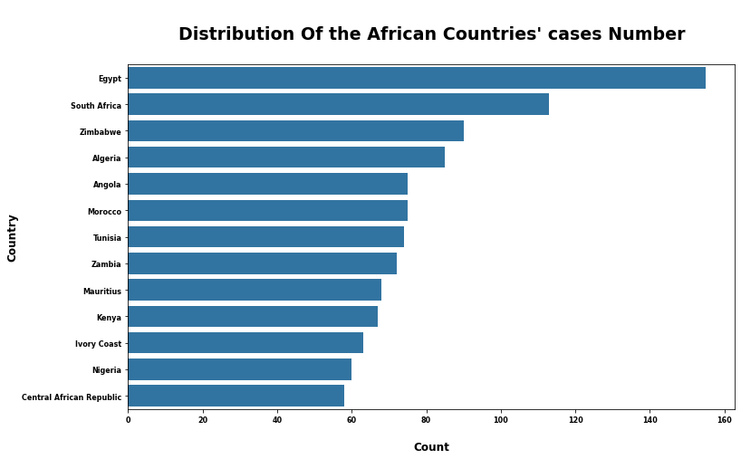

- **Egypt** has the highest number of cases, followed by **South Africa** and **Zimbabwe**.
- **Central African Republic, Nigeria** and **Ivory Coast** have the lowest number of cases in order.

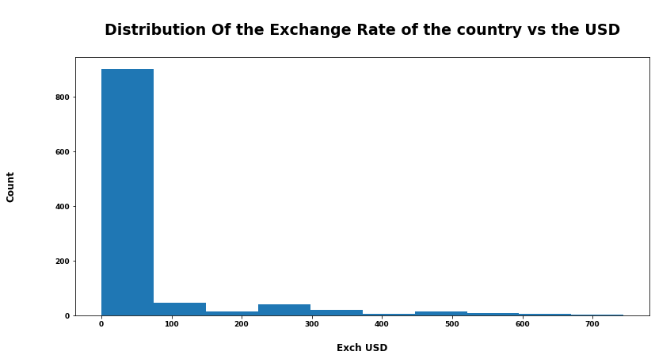

- **Most exchange rates** of the countries are between **0 and 80** (The National Currency per USD).
- **50%** of cases the exchange rate is **0.9**.
- **In fewer cases** the exchange rates from **80 to 145 and from 230 to 290** come in second place.
- **The Fewest cases** are the exchange rates between **380 and 740**.

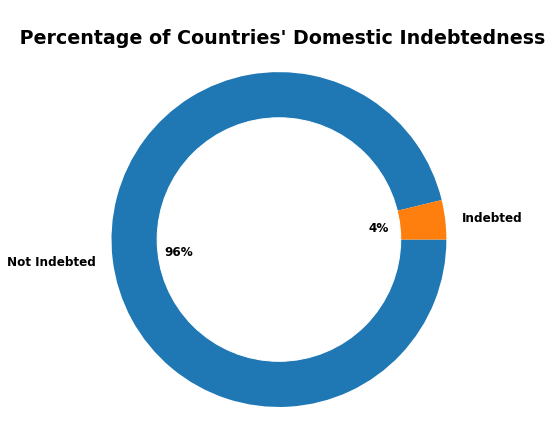

- **In 96% of the cases, countries are not Domestic indebted.**

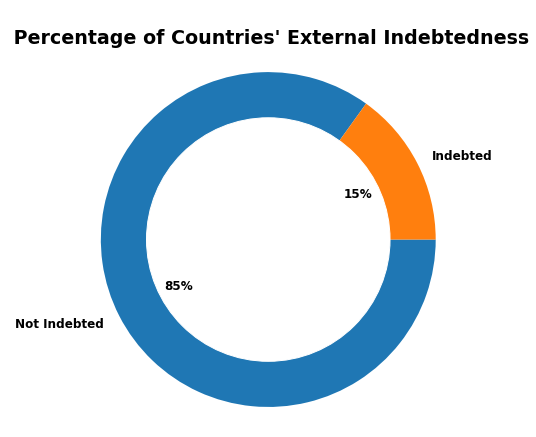

- **In 85% of the cases, countries are not external indebted.**
- **As shown, sovereign external debts are more than the domestic debts in the most cases.**

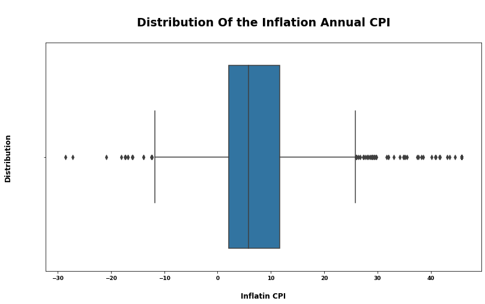

- **The Inflation annual CPI in the most cases is high with the percentages between 2% and 12%.**
- **The negative percentages express the decreasing in the inflation indicator, the lowest percentage it reached was -28.5%**.

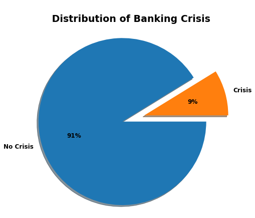

- **There in no Banking Crisis in 91% of the cases**.

## Bivariate Exploration

> Investigate relationships between pairs of variables in the dataset.

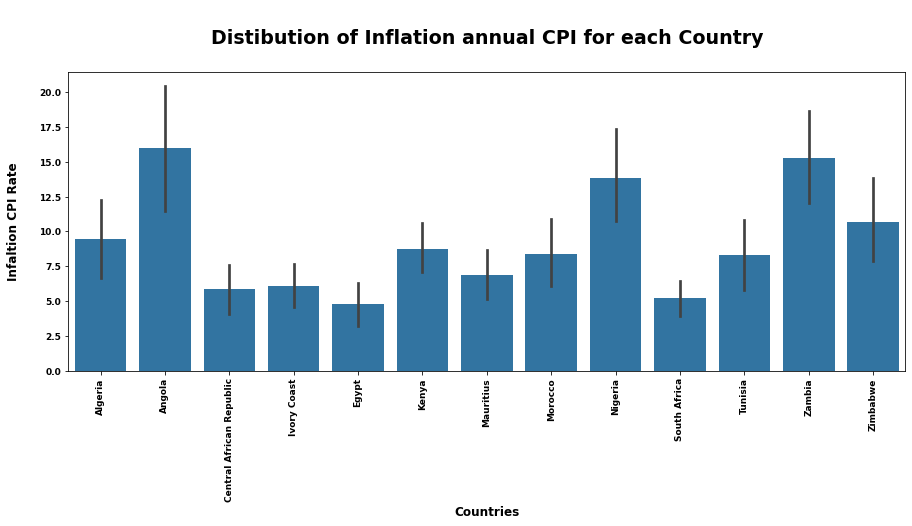

- **Almost all the countries suffer from inflation at different rates.**
- **Angola**, **Zambia** and **Nigeria** have the **highest increasing in the Inflation annual CPI rate** in order.
- **Egypt** and **South Africa** have the **lowest increasing in the Inflation annual CPI rate**

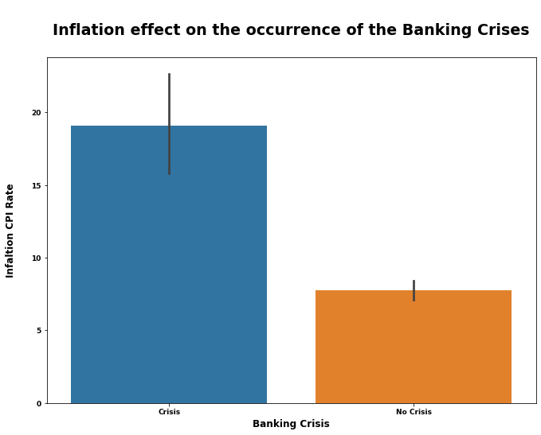

- **It is obvious that the increasing in the inflation rates cause increasing in the probability of the banking crisis occurrence.**

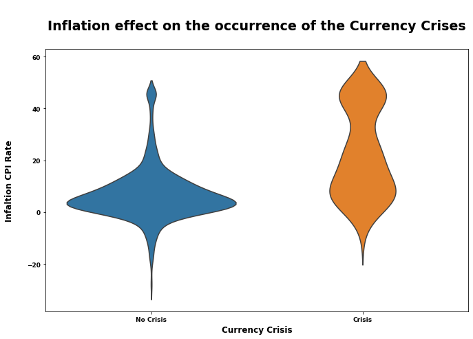

- **According to the distributions, when the Inflation CPI rate is close to or equal zero, The incidence of currency crisis is much lower than the no crisis cases.**
- **The increasing in the inflation rate cause increasing in the currency crisis.**

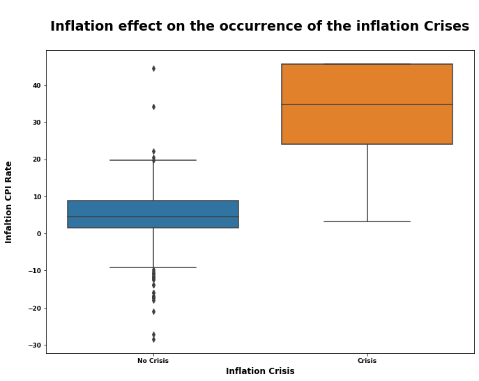

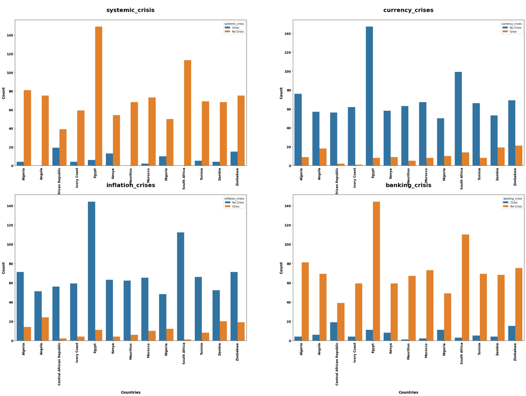

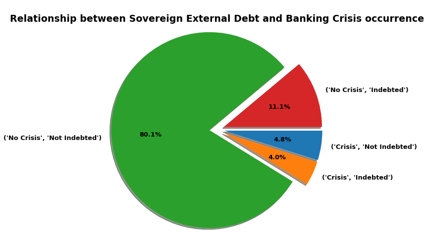

- **The percentage of both No Crisis and Not Indebted cases is 80.1%, while the percentage of the country is being Indebted and there is no crisis is 11.1% and it's higher than the banking crisis occurrence while the country isn't Indebted which is 4.8%**

## Multivariate Exploration

> Create plots of three or more variables to investigate the data even further.

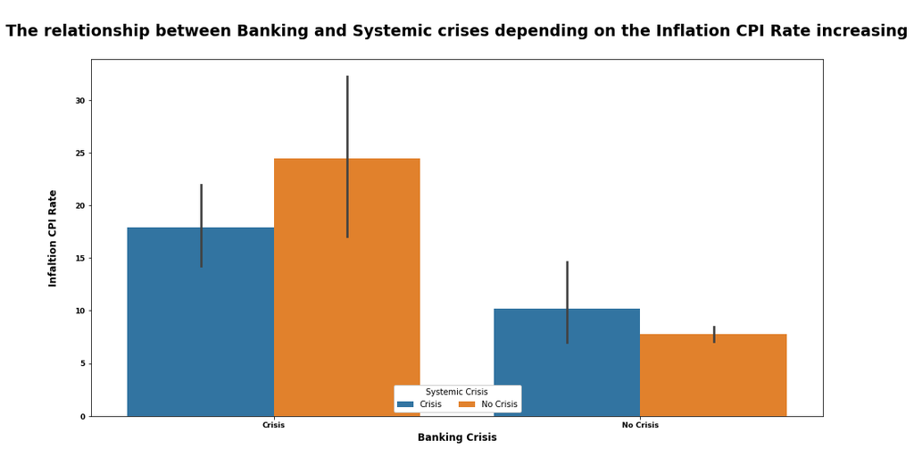

- **In the presence of the Banking Crisis while the increasing of the Inflation CPI Rate, we can see that the No Systemic Crisis Cases is higher than the Systemic Crisis occurrence.**
- **According to this exploration, we can say that there is no strong relationship between Banking and Systemic Crisis while the increasing of the Inflation CPI Rate and none of them affects the other directly, not like we've explored in the previous one.**

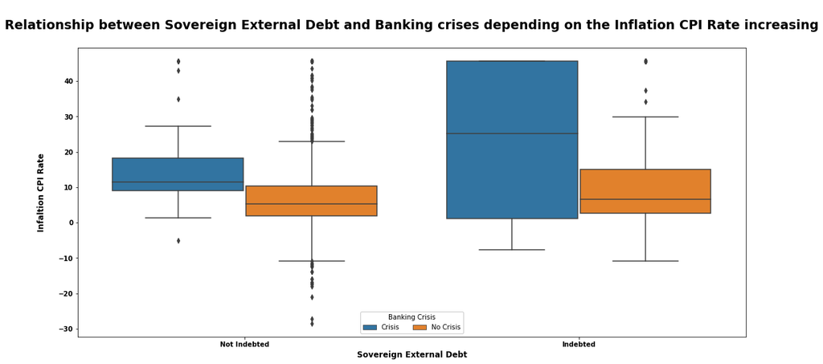

- **When the country is in Sovereign External Indebted and the Inflation Rate increases, The occurrence rate of the Banking Crisis is much higher than the No Banking Crisis cases.**
- **The Sovereign External Debt affects the Banking Crisis occurrence during the increasing of the Inflation CPI Rate.**

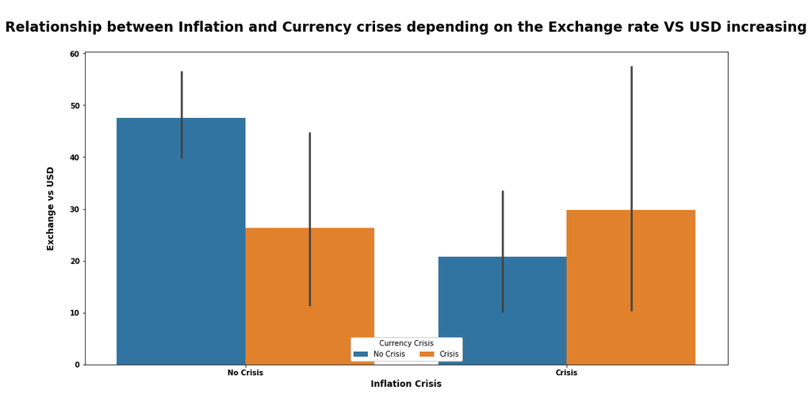

- **During the increasing of the exchange rate vs the USD, The No Currency crisis cases is higher than the crisis occurrence, but in the Inflation Crisis occurrence we can see that the Currency Crisis Occurrence is higher than the No Currency cisis cases.**
- **The Inflation Crisis occurrence affects on the occurence and the increasing in the Currency Crisis occurrence.**